# Mapas en R

Explicación

R cuenta con varios paquetes de funciones que permiten manipular información espacial con facilidad. A continuación vamos a aprender a combinarlos con las herramientas que hemos aprendido en las clases anteriores, para hacer análisis geográfico y crear nuestros propios mapas.

### Requisitos

```r
#install.packages(c("sf","cartography"))
```

### Datos espaciales [^1]

El atributo que distingue a los datos georreferenciados, lo que los hace merecer ese nombre, es que representan ubicaciones exactas sobre la superficie de la Tierra. Representar en forma precisa una posición sobre la superficie terrestre es un todo un reto. Para empezar, la Tierra tiene una forma irregular. A pesar de cómo solemos imaginarla y dibujarla, no es una esfera perfecta sino que está “achatada” en los polos, dificultando la matemática necesaria para comparar posiciones y medir distancias.

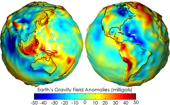

Luego, está el problema de cómo mostrar sobre papel impreso, o en una pantalla digital, -superficies planas- rasgos geográficos que pertenecen a una superficie tridimensional esférica. La solución a estos problemas toma la forma de sistemas de coordenadas de referencia (CRS por sus siglas en inglés), y de proyecciones cartográficas.

Los CRS son un sistema de números que definen ubicaciones sobre la superficie de la Tierra; funcionan como direcciones. El tipo de CRS más conocido es el que usa latitud y longitud, para definir posiciones en los ejes norte-sur y este-oeste.

Las proyecciones cartográficas son instrucciones para traducir a un plano la disposición de puntos ubicados en la esfera terrestre. Algo así como las instrucciones para dibujar en dos dimensiones las disposición de fronteras, accidentes geográficos, calles o cualquier otro objeto que se extiende sobre la superficie curva del planeta. Como en toda traducción, hay algo que se pierde en el proceso. Todo los mapas “mienten”, en el sentido en que presentan una versión distorsionada de la superficie de terrestre. Esto es inevitable; no existe forma de pasar de la esfera al plano sin distorsionar la forma, la superficie, la distancia o la dirección de los rasgo geográficos. Existen muchísimas proyecciones distintas, cada una pensada para minimizar alguno de los tipos de distorsión, o para encontrar una solución de compromiso que los balancee.

[Proyecciones](https://map-projections.net/singleview.php)

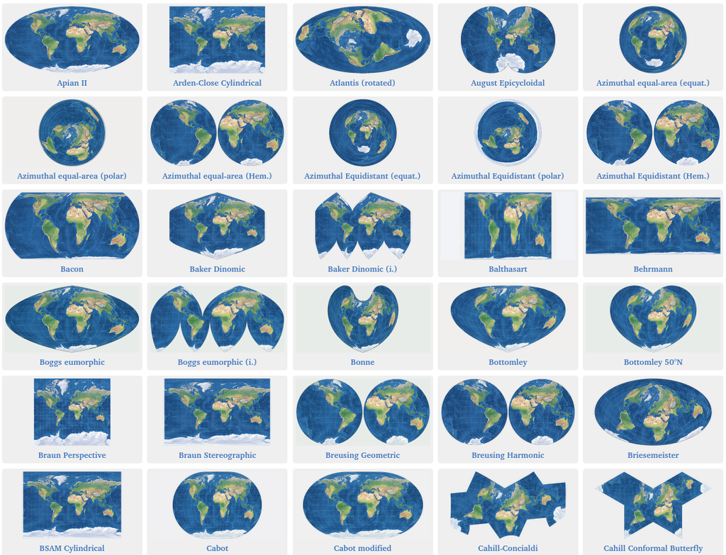

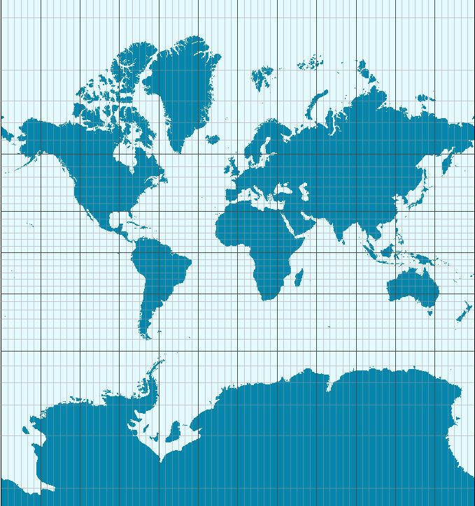

En la práctica, si trabajamos en forma frecuente con archivos georreferenciados vamos a sufrir tarde o temprano de problemas de coordenadas o proyección. El más común de ellos: tener una fuentes de datos geográficos que no podemos comparar con otras, porque desconocemos el sistema de coordenadas que se usó para crearla; es decir, no podemos saber a que posición sobre el planeta corresponde cada observación en los datos.

### Formatos de archivos

El formato más común es el denominado “shapefile”, inventado por la empresa ESRI (los creadores del software ArcGIS). Es un formato incómodo porque guarda la información en varios archivos distintos, que suelen ser combinados en un archivo .zip para su distribución. Un inconveniente aún mayor es que los nombres de las variables en un shapefile deben tener 10 caracteres o menos, lo que facilita el uso de abreviaturas ininteligibles. A pesar de éstos y otros detrimentos, el formato es tan común que se ha vuelto sinónimo de archivo con información geográfica, y resiste a pesar de los esfuerzos por reemplazarlo con alternativas más modernas. Una de ellas es “GeoJSON”, un estándar abierto que corrige los dos inconvenientes mencionados antes. **Para nuestros ejercicios usaremos datos geográficos en formato geojson.**

### Explorando un archivo con información geográfica

```r
library(sf)
library(cartography)
library(tidyverse)
```

En este caso vamos a usar el geojson de departamentos disponible en [link](https://datos.gob.ar/is/dataset/ign-unidades-territoriales/archivo/ign_01.03.02)

También se creo recientemente el repositorio [IDERA](https://www.idera.gob.ar/)

```r
departamentos <- st_read("../datasets/departamentos/departamento.geojson")
```

Como con cualquier otro dataset, comenzamos nuestra exploración pidiendo su resumen:

```r
summary(departamentos)
```

```
                      FNA                GNA              NAM                                            SAG
 Departamento Capital   : 11   Comuna      : 15   Capital   : 11   ARBA - Gerencia de Servicios Catastrales:135
 Departamento San Martín:  5   Departamento:380   Rivadavia :  5   IGN                                     : 93
 Departamento Rivadavia :  4   Partido     :135   San Martín:  5   Direc. Grl. de Catastro                 : 92
 Departamento 25 de Mayo:  3                      25 de Mayo:  4   Direc. Grl. de Inmuebles                : 39
 Departamento 9 de Julio:  3                      9 de Julio:  4   Direc. de Geodesia y Catastro           : 28
 Departamento Belgrano  :  3                      Avellaneda:  3   Direc. Pcial. de Catastro y Cartografía : 25
 (Other)                :501                      (Other)   :498   (Other)                                 :118
      IN1               geometry
 94028  :  2   MULTIPOLYGON :530
 02007  :  1   epsg:4326    :  0
 02014  :  1   +proj=long...:  0
 02021  :  1
 02028  :  1
 (Other):523
 NA's   :  1
```

Podemos sacar en limpio varias cosas. IN1, es el código que identifica cada departamento.

sag: Autoridad de fuente (SAG) responsable de la administración del dato de estas entidades. fna: Nombre geográfico (FNA) o nombre largo del departamento. gna: Término genérico (GNA) o tipo de jurisdicción de la división político-territorial. nam: Término específico (NAM) o nombre corto del departamento.

### Viasualizacion de archivos de información geográfica

La función `plot` aplciada a un dataset con información geográfica nos va a graficar automáticamente todos los campos del dataset.

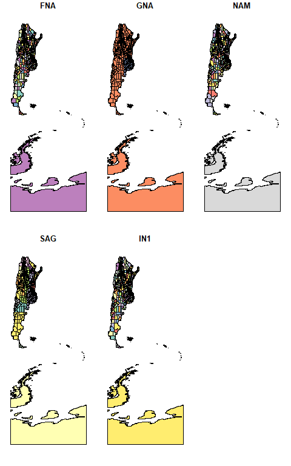

```r
plot(departamentos)
```

Para ver un solo campo debemos seleccionar una única columna (FNA en este caso) y la columna con información de los polígonos (“geometry”)

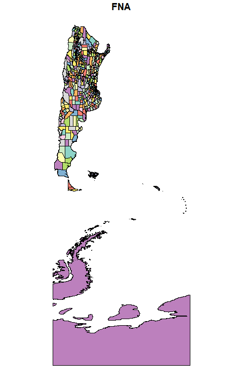

```r
plot(departamentos[,c("FNA","geometry")])
```

Si queremos hacer foco en Argentina continental podemos aplicar dos métodos:

- El primero es filtrar aquellos departamentos que no queremos mapear
- El segundo es recortar el área del mapa (esto lo veremos después)

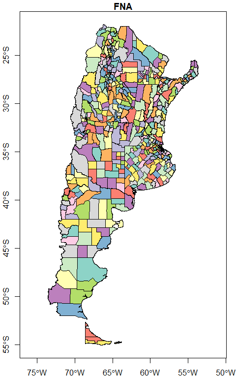

```r
#Filtramos departamentos Antartida e islas del Atlántico Sur
arg_continental<-departamentos %>% filter(!NAM %in% c("Antártida Argentina","Islas del Atlántico Sur"))
plot(arg_continental[,c("FNA","geometry")], axes=TRUE)
```

Tambien podemos graficar directamente la geomtería del objeto geográfico aplicando la función `plot` sobre la salida de la función `st_geometry`.

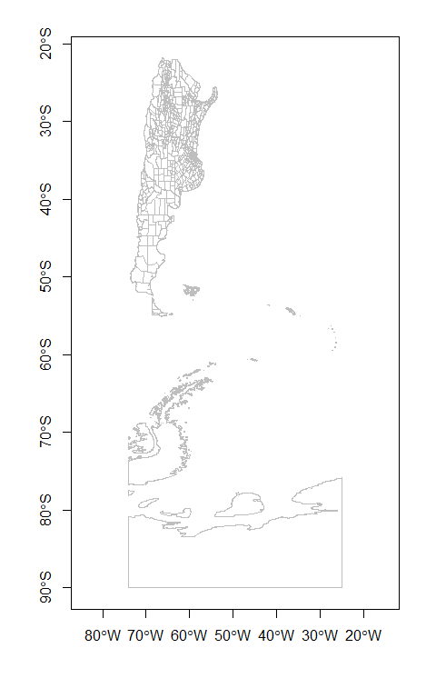

```r
plot(st_geometry(departamentos), col = NA, border = "grey",axes = TRUE)
```

La figura parece un poco angosta. Veamos el CRS de esta figura

```r
st_crs(departamentos)
```

```
Coordinate Reference System:
  EPSG: 4326
  proj4string: "+proj=longlat +datum=WGS84 +no_defs"
```

Si quisiéramos descartar la Antártida Argentina para concentrarnos en el continente tenemos que recortar el bounding box.

```r
st_bbox(departamentos) #Vemos el bbox
```

```
     xmin      ymin      xmax      ymax
-74.00000 -90.00000 -25.00000 -21.78113
```

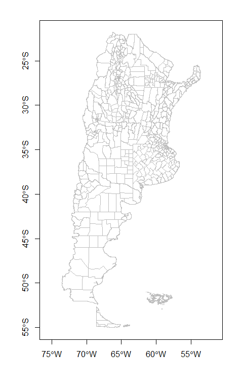

```r
box = c(xmin = -74 , ymin = -55, xmax = -45, ymax = -21) #construimos un box que se enfoque en el continente
departamentos<-st_crop(departamentos, box) #cortamos
plot(st_geometry(departamentos),col = NA, border = "grey", axes=T) #graficamos Argentina continental
```

```r
#https://epsg.io/?q=Argentina%20kind%3APROJCRS
mapa_oficial<-departamentos %>% st_transform(crs = 5345)
st_crs(mapa_oficial)
```

```
Coordinate Reference System:
  EPSG: 5345
  proj4string: "+proj=tmerc +lat_0=-90 +lon_0=-66 +k=1 +x_0=3500000 +y_0=0 +ellps=GRS80 +towgs84=0,0,0,0,0,0,0 +units=m +no_defs"
```

Como podemos ver la proyección de mercator transverse no distorsiona la distancias de Argentina.

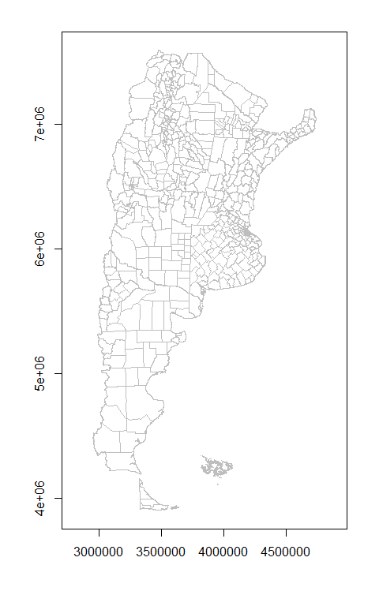

```r
plot(st_geometry(mapa_oficial), col = NA, border = "gray",axes = TRUE)
```

### Mapear datos externos

Para poder mapear datos externos es necesario unir el dataset externo con el dataset que tienen la información geográfica. Esto lo hacemos con las funciones `join` que vimos en la segunda clase.

```r
#Genero variables ID.Provincia y ID.Departamento para join con Estimaciones
mapa_oficial <- mapa_oficial %>% mutate(ID.Provincia = substr(IN1, 1, 2),
                              ID.Departamento = substr(IN1, 3, 6)) %>%
                      mutate(ID.Provincia = as.integer(ID.Provincia),
                              ID.Departamento = as.integer(ID.Departamento))
#Cargo dataset de estimaciones agrícolas
estimaciones <- read.table(file = '../datasets/Estimaciones.csv',sep=";", header = TRUE)
#Selecciono cultivo soja y campaña 2016/17
estimaciones <- estimaciones %>%   filter(Cultivo %in% c("Soja total","Trigo total","Maíz") ) %>%
  mutate(Rendimiento..Kg.Ha. = as.numeric(Rendimiento..Kg.Ha.))
#Join de tablas
estimaciones  <-  mapa_oficial %>% full_join(estimaciones, by = c("ID.Departamento","ID.Provincia"))
estimaciones  %>% sample_n(8)
```

```
Simple feature collection with 8 features and 17 fields
geometry type:  POLYGON
dimension:      XY
bbox:           xmin: 3676624 ymin: 5822743 xmax: 4288542 ymax: 6939874
epsg (SRID):    5345
proj4string:    +proj=tmerc +lat_0=-90 +lon_0=-66 +k=1 +x_0=3500000 +y_0=0 +ellps=GRS80 +towgs84=0,0,0,0,0,0,0 +units=m +no_defs
                       FNA          GNA         NAM                                            SAG   IN1 ID.Provincia
1      Partido de Mercedes      Partido    Mercedes       ARBA - Gerencia de Servicios Catastrales 06532            6
2      Partido de Ayacucho      Partido    Ayacucho       ARBA - Gerencia de Servicios Catastrales 06042            6
3         Partido de Maipú      Partido       Maipú       ARBA - Gerencia de Servicios Catastrales 06511            6
4     Departamento Caseros Departamento     Caseros Servicio de Catastro e Información Territorial 82014           82
5         Partido de Colón      Partido       Colón       ARBA - Gerencia de Servicios Catastrales 06175            6
6      Departamento Robles Departamento      Robles                        Direc. Grl. de Catastro 86161           86
7 Departamento Río Primero Departamento Río Primero                        Direc. Grl. de Catastro 14105           14
8     Partido de Pergamino      Partido   Pergamino       ARBA - Gerencia de Servicios Catastrales 06623            6
```

[output cut: 18 more lines]

Ahora podemos mapear la información. El paquete [Cartography](https://github.com/riatelab/cartography) tiene muchas funcionalidades.

Mapas choropleth se aplica la función `choroLayer`. Al igual que con ggplot los gráficos se construyen por capas. Tampoco es necesario recordar el código de memoria. Cuando haya que usarlo podemos visitar el [machete](http://riatelab.github.io/cartography/vignettes/cheatsheet/cartography_cheatsheet.pdf).

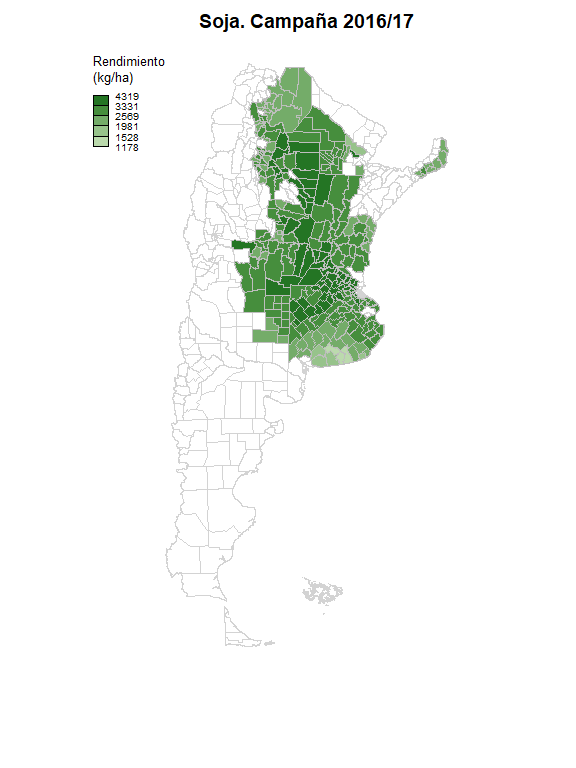

```r
plot(st_geometry(mapa_oficial),col = NA,border = "light gray", main="Soja. Campaña 2016/17")
choroLayer(
  x = estimaciones  %>% filter(Campana=="2016/17", Cultivo=="Soja total"),
  var = "Rendimiento..Kg.Ha.",
  method = "geom",
  nclass=5,
  col = carto.pal(pal1 = "green.pal", n1 = 6),
  border = "gray",
  lwd = 0.5,
  legend.pos = "topleft",
  legend.title.txt = "Rendimiento\n(kg/ha)",
  add = TRUE
)
```

Combinándolo con Tydiverse podemos transformar los datos fácilmente y mapearlos. Por ejemplo, a continuación cambiamos la unidades y el nombre de la variable que registra el rendimiento de la soja.

```r
estimaciones  <- estimaciones %>% rename(Rinde = Rendimiento..Kg.Ha.) %>% mutate(Rinde = Rinde/1000)
plot(st_geometry(mapa_oficial),col = NA,border = "light gray", main="Campaña 2016/17")
choroLayer(
  x = estimaciones  %>% filter(Campana=="2016/17", Cultivo=="Soja total"),
  var = "Rinde",
  method = "geom",
  nclass=5,
  col = carto.pal(pal1 = "green.pal", n1 = 6),
  border = "gray",
  lwd = 0.5,
  legend.pos = "topleft",
  legend.title.txt = "Rendimiento\n(tn/ha)",
  add=T
)
```

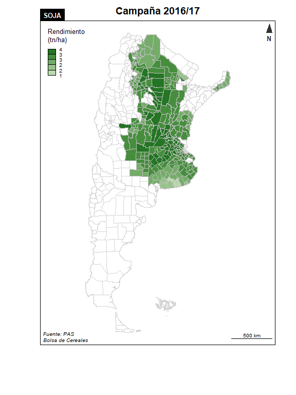

```r
layoutLayer( title = "SOJA", tabtitle = TRUE, frame = TRUE, author = "Bolsa de Cereales", sources = "Fuente: PAS",  north = TRUE,  scale = 500)
```

También se pueden hacer mapas con más chiches

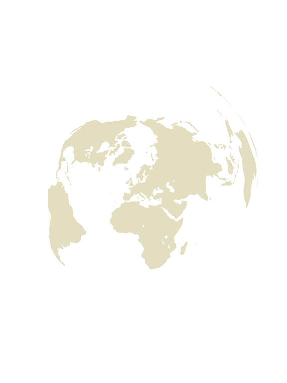

```r
data("nuts2006")
mundo <- st_as_sf(world.spdf)
plot(st_geometry(mundo), col  = "#E3DEBF", border = NA)
```

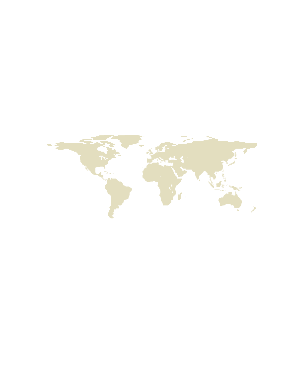

```r
mundo <-  mundo %>% st_transform(crs = 4326)
plot(st_geometry(mundo), col  = "#E3DEBF", border = NA)
```

```r
mapa_oficial <-  mapa_oficial %>% st_transform(crs = 4326)
estimaciones <-  estimaciones %>% st_transform(crs = 4326)
plot(st_geometry(mundo), col  = "#E3DEBF", border = NA, ylim=c(-40,-20), xlim=c(-70,-52), main="Campaña 2016/17")
plot(st_geometry(mapa_oficial), col  = NA, border = "white",add = TRUE)
```

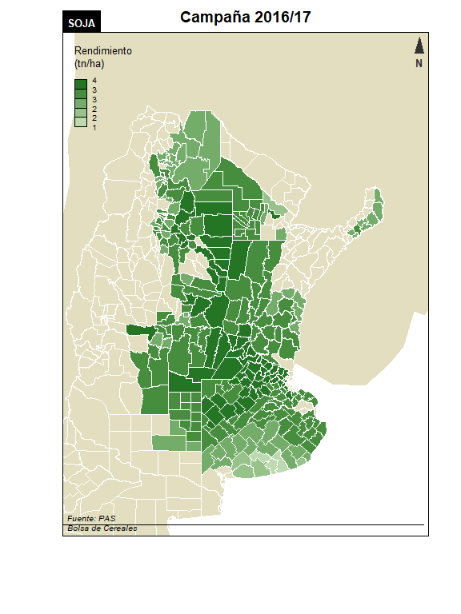

```r
choroLayer(
  x = estimaciones  %>% filter(Campana=="2016/17", Cultivo=="Soja total"),
  var = "Rinde",
  method = "geom",
  nclass=5,
  col = carto.pal(pal1 = "green.pal", n1 = 6),
  border = "white",
  lwd = 0.5,
  legend.pos = "topleft",
  legend.title.txt = "Rendimiento\n(tn/ha)",
  add=T,colNA = "light gray"
)
layoutLayer( title = "SOJA", tabtitle = TRUE, frame = TRUE, author = "Bolsa de Cereales", sources = "Fuente: PAS",  north = TRUE,  scale = 500)
```

### Mapas con Ggplot

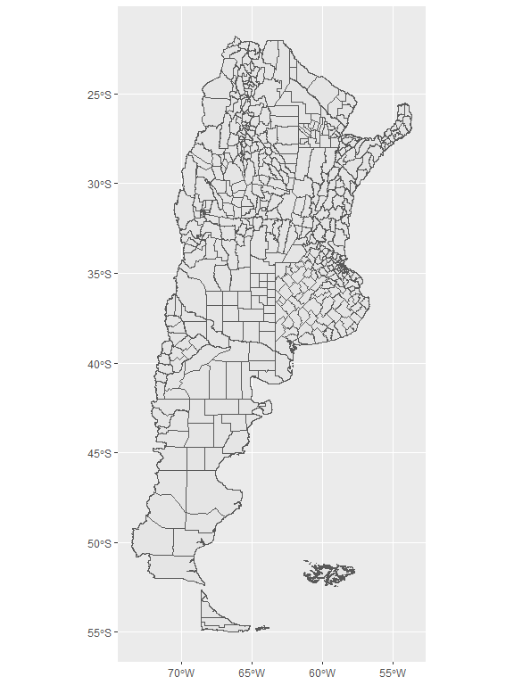

```r
g1<-ggplot() + geom_sf(data = mapa_oficial)
g1
```

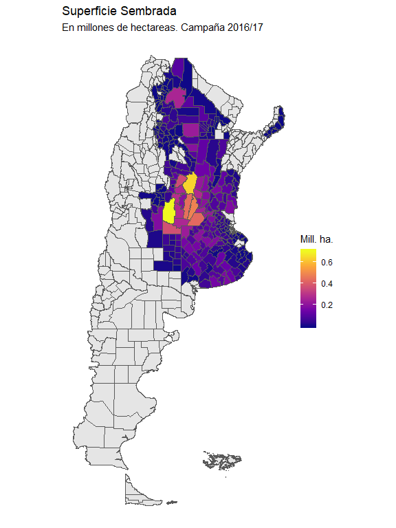

```r
g2 <- g1 + geom_sf(data = estimaciones  %>% filter(Campana=="2016/17", Cultivo=="Soja total") ,
                   mapping = aes(fill = Sup..Sembrada..Ha./1000000))+
  theme(legend.position = 'bottom')+
  scale_fill_viridis_c(option = 'C') +
  labs(title = "Superficie Sembrada ",
       subtitle = "En millones de hectareas. Campaña 2016/17 ",
        fill = "Mill. ha.")+
  theme_void()
g2
```

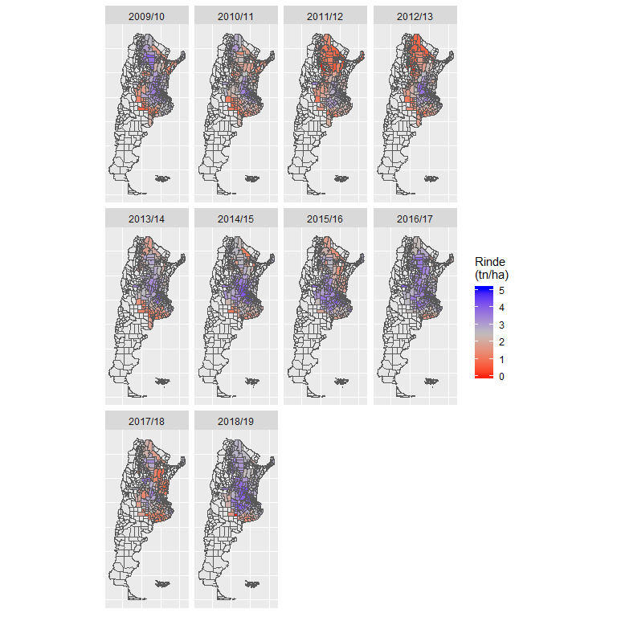

```r
ggplot()  + geom_sf(data = mapa_oficial)+
  geom_sf(data = estimaciones %>% filter(Cultivo=="Soja total", ID.Campaña>40), mapping = aes(fill= Rinde))+ # the input data
  facet_wrap(~ Campana)+
  scale_fill_gradient2(low = "red", mid = "grey", high = "blue", # colors
    midpoint = 2.5, name = "Rinde\n(tn/ha)") + # legend options
  theme(axis.text = element_blank(), # change the theme options
    axis.title = element_blank(), # remove axis titles
    axis.ticks = element_blank()) # remove axis ticks
```

### Leaflet

```r
#install.packages("leaflet")
library(leaflet)
leaflet() %>%
  addTiles() %>%
  addPolygons(data = mapa_oficial %>% filter(FNA=="Comuna 1" | FNA=="Comuna 13" ))
```

[interactive chart not shown]

### Referecias

- [Geocomputation wtih R](https://bookdown.org/robinlovelace/geocompr/)
[^1]: Esta clase es una adaptación del [capitulo 6 de Ciencia de Datos para gente sociable de A. Vazquez Burst](https://bitsandbricks.github.io/ciencia_de_datos_gente_sociable/informacion-geografica-y-mapas.html#los-datos-georreferenciados).